# Early Childbearing in Kenya

Annette Chesir

2025-7-1

# 1 Introduction

Early childbearing, defined as giving birth before the age of 18, is a critical health and social issue. This report explores the prevalence and patterns of early childbearing in Kenya using data from the 2022 Kenya Demographic and Health Survey (DHS).

# 2 Study Objectives

1. To determine the prevalence of early childbearing (before age 18) among women in Kenya.
2. To examine socio-demographic factors—such as education level, wealth status, and place of residence—associated with early childbearing.

# 3 Methods

We used the women’s individual recode dataset `KEIR72FL.DTA`, accessed from the DHS program and stored in the `data/Kenya_IR72DT/` folder. Relevant variables include:

- `v212`: Age at first birth
- `v106`: Education level
- `v190`: Wealth index
- `v025`: Type of residence

# 4 Findings

## 4.1 Prevalence of Early Childbearing

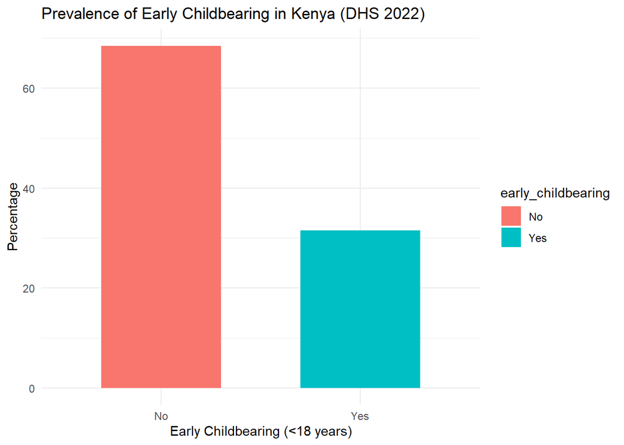

## 4.2 By Education Level

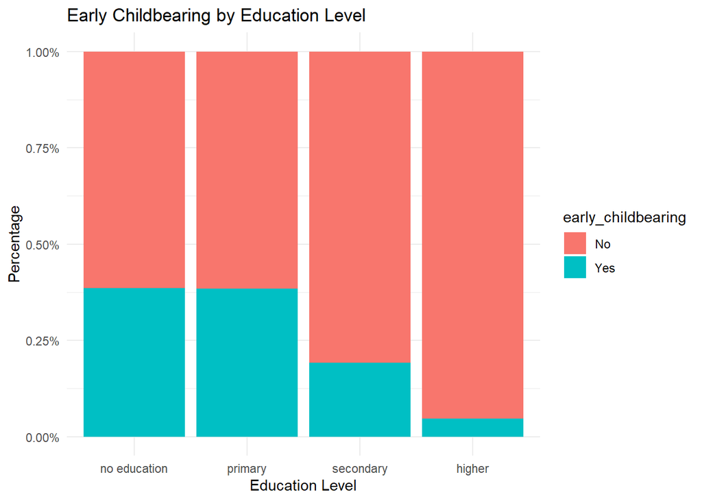

#education summary

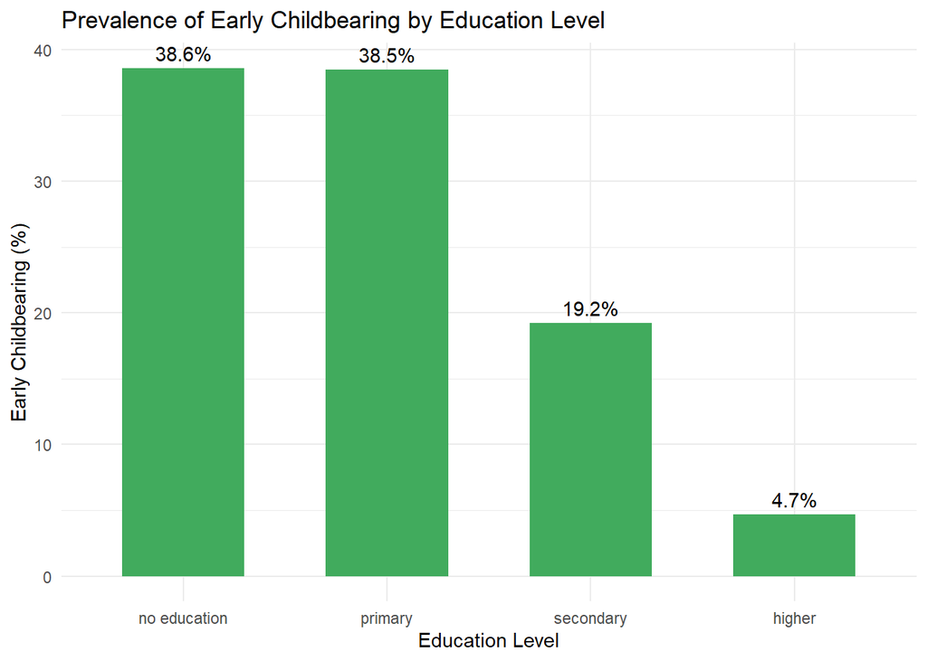

## 4.3 By Wealth Index

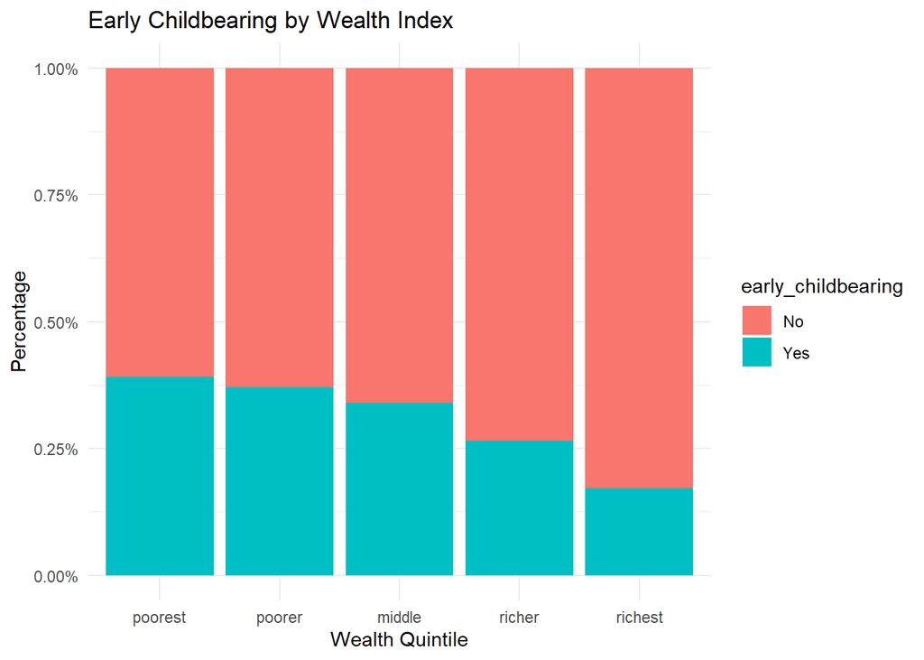

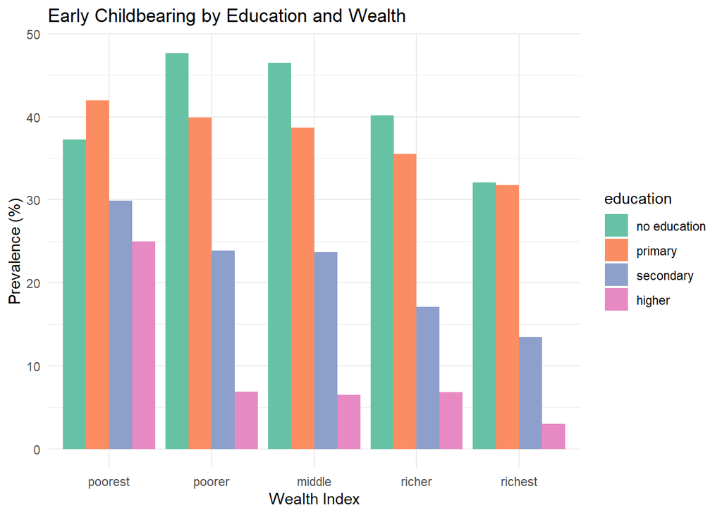

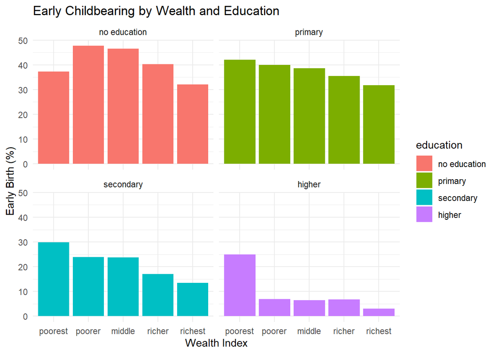

## 4.4 By Residence

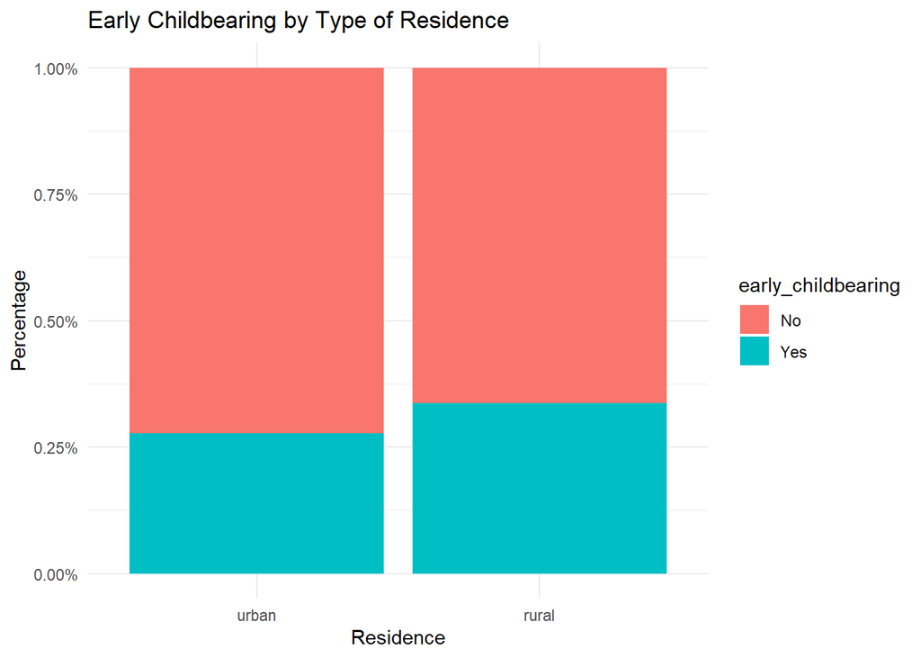

#Distribution of women residents

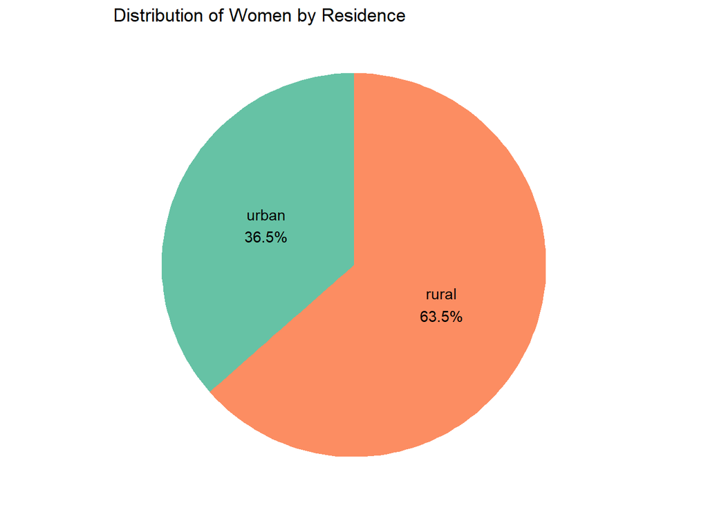

## 4.5 Distribution of Age at First Birth

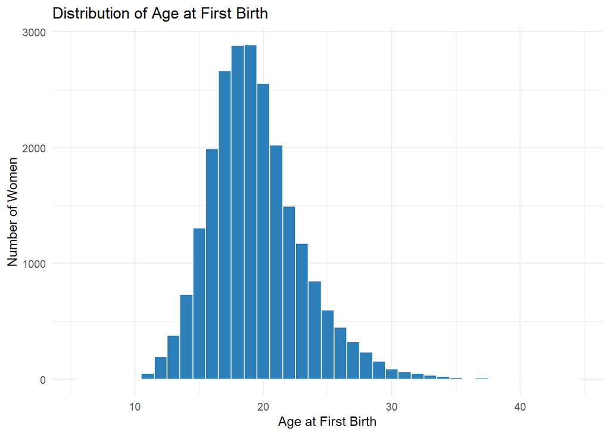

## density plot

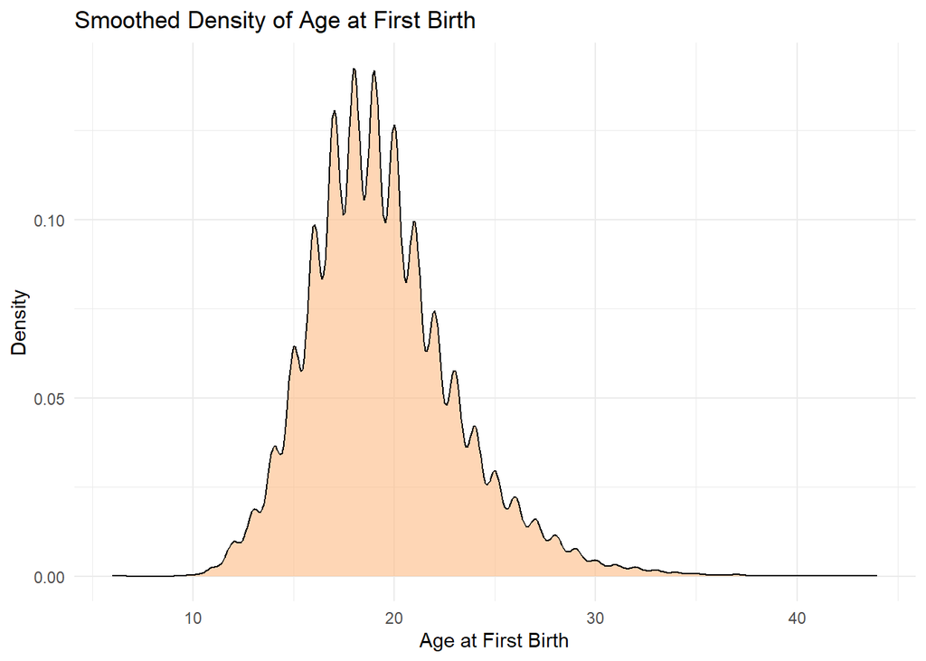

#age at first birth by education

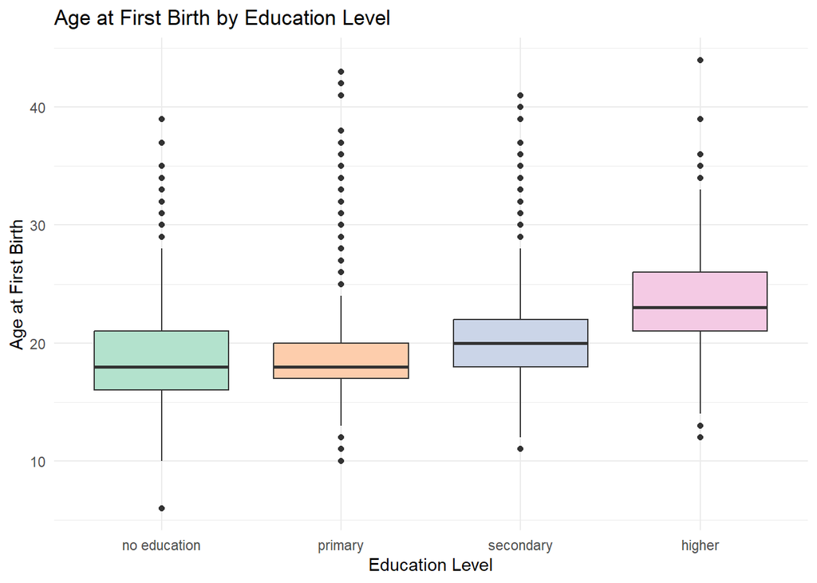

## 4.6 Summary Table

Early Childbearing by Education, Wealth, and Residence

|  | Wealth Index | Residence | Total Women | Early Births | Early Birth (%) |
| --- | --- | --- | --- | --- | --- |
| no education | poorest | urban | 276 | 90 | 32.6 |
|  | poorest | rural | 2522 | 953 | 37.8 |
|  | poorer | urban | 94 | 38 | 40.4 |
|  | poorer | rural | 214 | 109 | 50.9 |
|  | middle | urban | 111 | 56 | 50.5 |
|  | middle | rural | 104 | 44 | 42.3 |
|  | richer | urban | 197 | 75 | 38.1 |
|  | richer | rural | 37 | 19 | 51.4 |
|  | richest | urban | 185 | 59 | 31.9 |
|  | richest | rural | 2 | 1 | 50.0 |
| primary | poorest | urban | 512 | 233 | 45.5 |
|  | poorest | rural | 2164 | 892 | 41.2 |
|  | poorer | urban | 647 | 260 | 40.2 |
|  | poorer | rural | 2740 | 1090 | 39.8 |
|  | middle | urban | 652 | 257 | 39.4 |
|  | middle | rural | 2249 | 866 | 38.5 |
|  | richer | urban | 1043 | 428 | 41.0 |
|  | richer | rural | 1150 | 350 | 30.4 |
|  | richest | urban | 1072 | 343 | 32.0 |
|  | richest | rural | 192 | 59 | 30.7 |
| secondary | poorest | urban | 86 | 27 | 31.4 |
|  | poorest | rural | 205 | 60 | 29.3 |
|  | poorer | urban | 230 | 56 | 24.3 |
|  | poorer | rural | 553 | 131 | 23.7 |
|  | middle | urban | 268 | 75 | 28.0 |
|  | middle | rural | 880 | 197 | 22.4 |
|  | richer | urban | 685 | 124 | 18.1 |
|  | richer | rural | 828 | 135 | 16.3 |
|  | richest | urban | 1262 | 177 | 14.0 |
|  | richest | rural | 264 | 29 | 11.0 |
| higher | poorest | urban | 6 | 1 | 16.7 |
|  | poorest | rural | 18 | 5 | 27.8 |
|  | poorer | urban | 22 | 2 | 9.1 |
|  | poorer | rural | 50 | 3 | 6.0 |
|  | middle | urban | 36 | 2 | 5.6 |
|  | middle | rural | 134 | 9 | 6.7 |
|  | richer | urban | 172 | 16 | 9.3 |
|  | richer | rural | 266 | 14 | 5.3 |
|  | richest | urban | 921 | 29 | 3.1 |
|  | richest | rural | 196 | 4 | 2.0 |

# 5 Discussion

Early childbearing remains a significant public health and development concern in Kenya. This analysis shows that one-third of women had their first birth before the age of 18, with marked disparities by education, wealth, and place of residence. Women with no education or from the poorest households had the highest prevalence. These findings call for targeted interventions to reduce adolescent pregnancies by improving education access, expanding reproductive health services, and addressing socio-economic vulnerabilities.

# 6 Conclusion

Addressing early childbearing is essential for Kenya’s progress on health and gender equity. Interventions should focus on keeping girls in school, improving access to adolescent-friendly health services, and engaging communities in shifting norms and expectations around early marriage and childbearing.